# FoRt: devtools

## `devtools`

## Paketentwicklung ohne `devtools`

Kommandozeilen-Befehle für ein Quellcode-Paket im Ordner `pkg`:

- `R CMD SHLIB pkg` kompiliert C/C++/Fortran-Code in `pkg/src`
- `R CMD check pkg` überprüft ob `pkg` ein valides R-Paket ist
- `R CMD build pkg` erzeugt *package bundle* `pkg.tar.gz` bzw. `pkg.zip`

Mit `devtools` direkt aus R heraus aufrufbar. (`devtools` läd jede Menge zusätzlicher Pakete wie `usethis`, `pkgbuild`, etc…)

## Wichtige `devtools` Befehle

- `create_package("pkg")` legt einen Ordner an der die Struktur eines R-Pakets hat.
- `usethis::use_<XX>` um wichtige Infrastruktur usw. festzulegen: Lizenzen, Vignetten, *unit testing* mit `testthat`, Website mit `pkgdown` …
- `load_all("pkg")`: simuliert `library("pkg")`.  
  Wichtiger Unterschied: in den mit `load_all()` geladenen Paketen sind *alle* Funktionen, auch die nicht-exportierten sichtbar um das Programmieren zu erleichtern.
- `test("pkg")`: lässt Tests in `inst/tests/` laufen und gibt Ergebnisse aus
- `document("pkg")`: lässt `roxygen2::roxygenize` über das Paket laufen um Hifeseiten, `NAMESPACE`, etc. zu aktualisieren

## Wichtigste `devtools` Befehle

Sobald alles zu funktionieren scheint:

- `check_man("pkg")` um erzeugte Hilfeseiten zu validieren
- `run_examples("pkg")` um Beispiele zu validieren
- `check("pkg")` um vollständiges `R CMD check` durchzuführen, mit den selben Optionen wie auf CRAN (aber nur auf einer R-Version!)
- `build("pkg")` und `build_win("pkg")` um *bundles* und *Windows binaries* zu erstellen.

## `devtools`: Ablauf (schematisch)

```r
## Initialisieren
library("devtools")
setwd("parent_directory")
create_package("my_package")
setwd("my_package")
use_testthat() #testthat infrastruktur anlegen
use_roxygen_md() #Markdown für roxygen benutzen

## Mit Inhalt füllen
# R-Dateien im Unterordner /R anlegen
# roxygen-Kommentare einfügen
# DESCRIPTION ausfüllen
# test-<XX>.R Dateien in tests/testthat/ anlegen
document() # erzeuge /man und NAMESPACE aus roxygen Kommentaren

## Dann iteriere
##1. Code editieren, Tests &  Dokumentation schreiben
##2. R CMD check laufen lassen:
check()
##3. WARNINGS, NOTES, ERRORS bearbeiten, also zurück zu 1

##Paket neu laden:
load_all()

# Installieren / Komplilieren
install()
build() # bzw: build_win()
```

## `devtools` & RStudio

`devtools`-Funktionalität in Rstudio eingebunden:

- `create_package()` legt auch ein Rstudio-Projektfile an
- damit dann in RStudio entsprechende Buttons und Hotkeys um Pakete zu dokumentieren, zu laden, zu testen, etc:

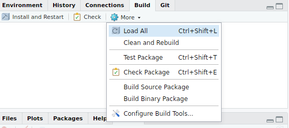

## R Pakete veröffentlichen: CRAN

`R CMD check pkg` überprüft ob `pkg` ein valides R-Paket ist.  
Für einen release auf CRAN muss hier ein sehr hoher Standard an formalen Kriterien eingehalten werden.

`devtools::release()` fragt eine entsprechende Checklist ab – hier kommen zu `devtools::check()` noch dazu:

- Überprüfung der *reverse dependencies* (s.a. `revdepcheck`-Paket)
- Überprüfung auf verschiedenen R-versionen auf verschiedenen Betriebssystemen (s.a. `rhub::check_for_cran()`)
- Viele weitere Details…